# Independent Project Week 13

##### 6.1.2.The Silhouette Method

```r
library(factoextra)
```

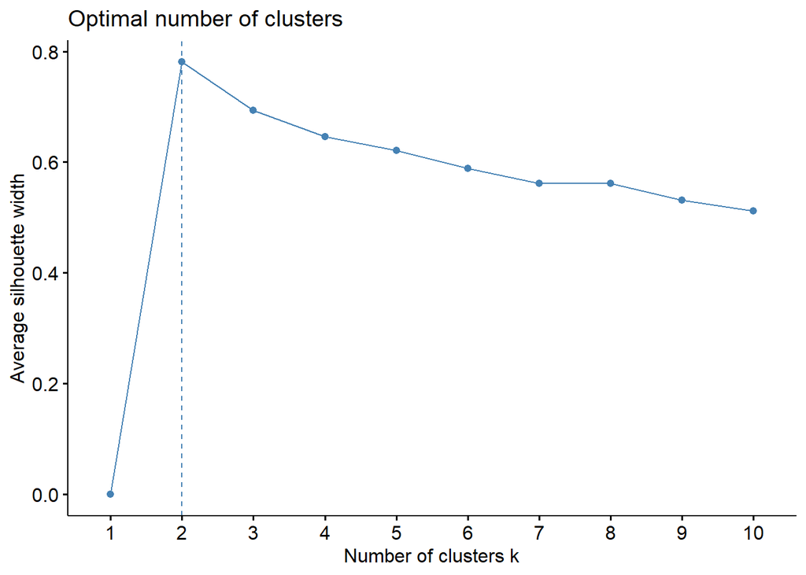

```r
library(cluster)
fviz_nbclust(online_shoppers, kmeans, method='silhouette')
```

After finding the preferred value for K as two, I applied it to my data and plotted the output.

```r
# Plottting K_Mean Clusters
result<- kmeans(online_shoppers,2)

# Previewing the no. of records in each cluster

result$size
```

```
## [1]   931 11268
```

```r
# Plotting the Clusters
```

There were two clusters of size 931 and 11268 .

I then used the fviz_cluster in the factoextra package to plot the clusters of my data as seen here.

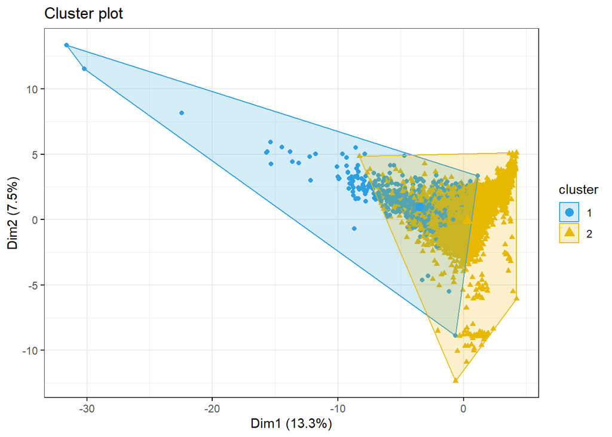

```r
fviz_cluster(result, data = online_shoppers,
             palette = c("#2E9FDF","#E7B800"),
             geom = "point",
             ellipse.type = "convex",
             ggtheme = theme_bw()
             )
```

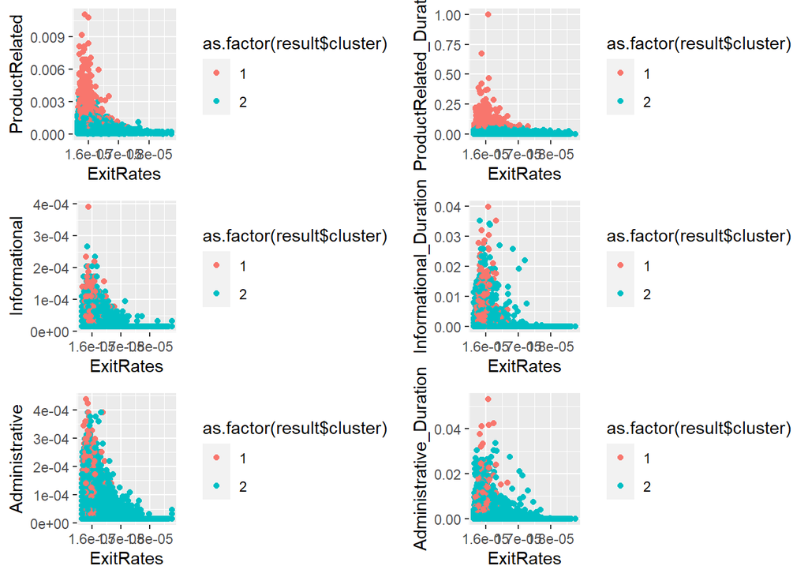

```r
p1 <- ggplot() + geom_point(data = online_shoppers,
             mapping = aes(x = ExitRates,
                                  y = ProductRelated,
                                  colour = as.factor(result$cluster)))

p2 <- ggplot() + geom_point(data = online_shoppers,
             mapping = aes(x = ExitRates,
                                  y = ProductRelated_Duration,
                                  colour = as.factor(result$cluster)))


p3 <- ggplot() + geom_point(data = online_shoppers,
             mapping = aes(x = ExitRates,
                                  y = Informational,
                                  colour = as.factor(result$cluster)))


p4 <- ggplot() + geom_point(data = online_shoppers,
             mapping = aes(x = ExitRates,
                                  y = Informational_Duration,
                                  colour = as.factor(result$cluster)))



p5 <- ggplot() + geom_point(data = online_shoppers,
             mapping = aes(x = ExitRates,
                                  y = Administrative,
                                  colour = as.factor(result$cluster)))





p6 <- ggplot() + geom_point(data = online_shoppers,
             mapping = aes(x = ExitRates,
                                  y = Administrative_Duration,
                                  colour = as.factor(result$cluster)))





figure <- ggarrange(p1, p2, p3, p4 , p5,p6 ,
                    ncol = 2, nrow = 3)+labs('Clusters of Exit Rate')


figure
```

I plotted clusters for the pages the clients visited and the exit rates , I noted that:

- Many of the users in the first cluster spent more time in the Product Related pages .
- However on the other Pages , there wasn’t a clear distinction on the clusters.

I also plotted the Month May variable against the pages

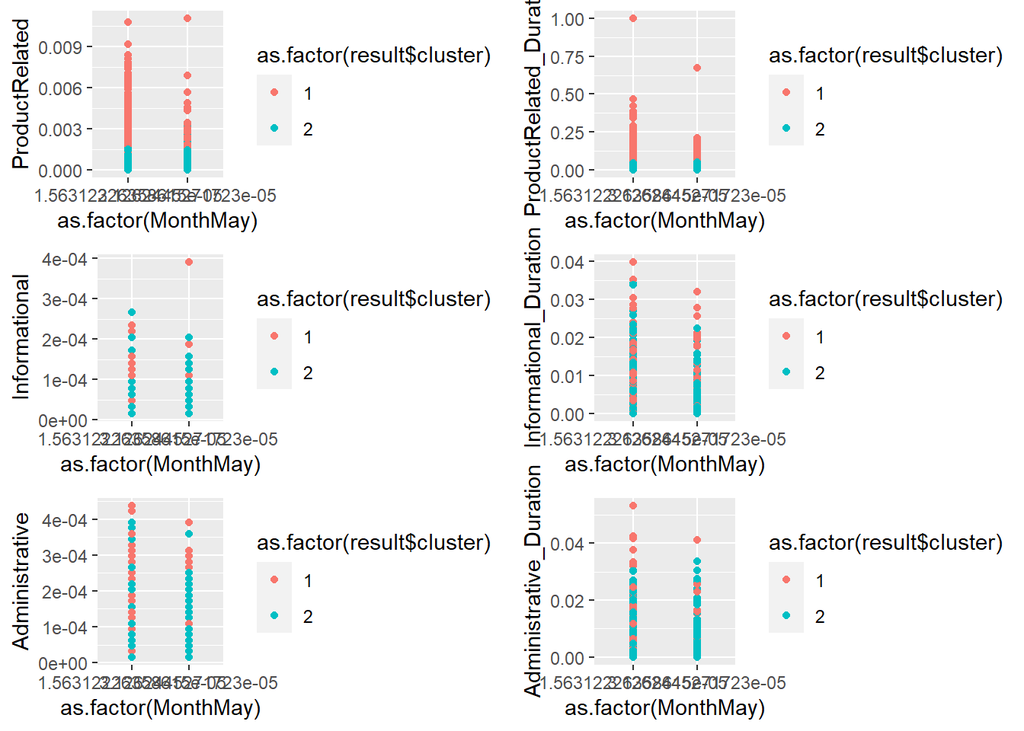

```r
p1 <- ggplot() + geom_point(data = online_shoppers,
             mapping = aes(x = as.factor(MonthMay),
                                  y = ProductRelated,
                                  colour = as.factor(result$cluster)))

p2 <- ggplot() + geom_point(data = online_shoppers,
             mapping = aes(x = as.factor(MonthMay),
                                  y = ProductRelated_Duration,
                                  colour = as.factor(result$cluster)))


p3 <- ggplot() + geom_point(data = online_shoppers,
             mapping = aes(x = as.factor(MonthMay),
                                  y = Informational,
                                  colour = as.factor(result$cluster)))


p4 <- ggplot() + geom_point(data = online_shoppers,
             mapping = aes(x = as.factor(MonthMay),
                                  y = Informational_Duration,
                                  colour = as.factor(result$cluster)))



p5 <- ggplot() + geom_point(data = online_shoppers,
             mapping = aes(x = as.factor(MonthMay),
                                  y = Administrative,
                                  colour = as.factor(result$cluster)))





p6 <- ggplot() + geom_point(data = online_shoppers,
             mapping = aes(x = as.factor(MonthMay),
                                  y = Administrative_Duration,
                                  colour = as.factor(result$cluster)))





figure <- ggarrange(p1, p2, p3, p4 , p5,p6 ,
                    ncol = 2, nrow = 3)+labs('Clusters of Month May')


figure
```

From these clusters , there is a clear distinction between cluster one and cluster two in the Product Related columns.

## 6.2. Hierarchical Clustering

Next , I carried out hierarchical clustering on the data and compared my findings to those of the K-Means Clustering.

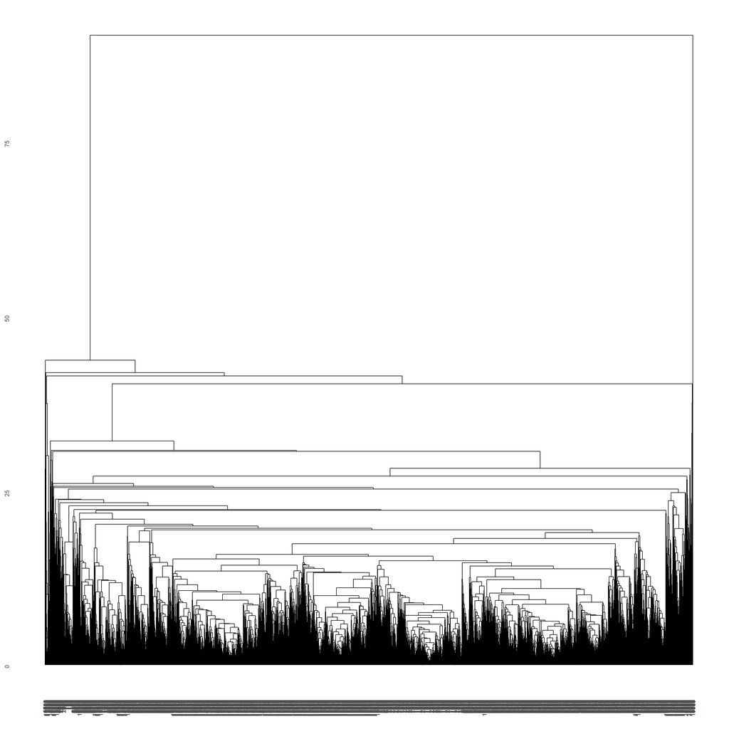

```r
library("ggdendro")
online_shoppers_hc <- na.omit(online_shoppers_hc)
clust <- scale(online_shoppers_hc)
d <- dist(as.matrix(clust) , method = 'manhattan')

#hc <- hclust(d, method = "ward.D2
library(flashClust)
cl <- flashClust(d, method = "average")
ggdendrogram(cl)
```

```r
#ggdendrogram(hc)
#clustergram(online_shoppers, k.range = 2:8, line.width = 0.004)
```

The output from my Hierarchical cluster dendrogram was very dense and thus extremely difficult for me to interpret.

# 7. Challenging the Solution.

Given that I applied both Hierarchical and K-Means Clustering in my analysis I decided to challenge the solution by applying DBSCAn Clustering in order to see how my results would vary from those of the K_means.

## 7.1. DBSCAN Clustering

```r
library(dbscan)

db<-dbscan(clust,eps=1,MinPts = 50 )
print(db)
```

```
## DBSCAN clustering for 12199 objects.
## Parameters: eps = 1, minPts = 50
## The clustering contains 4 cluster(s) and 11609 noise points.
##
##     0     1     2     3     4
## 11609   220   134   142    94
##
## Available fields: cluster, eps, minPts
```

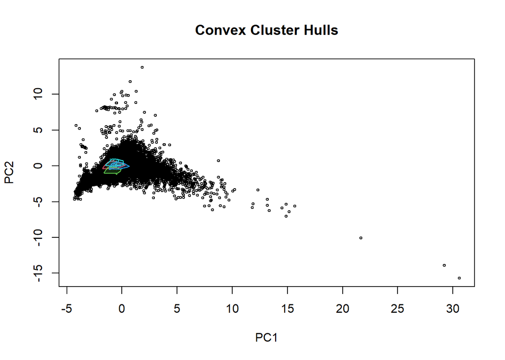

```r
hullplot(clust,db$cluster)
```

Many of the points in the DBSCAN clustering were recorder as noise , therefore this may not be the best , clustering method to use while classifying this particular dataset.

# 8. Conclusions and Recommendations

The team should purpose to collect better and more data , as the dataset had a large number of outliers , was very skewed and leptokurtic. I believe that more data would have made the dataset better.

From my analysis , I noted that the months that recorded the most activity were November, May , October and November. Furthermore the ProductRelated pages had more traffic compared to the Informational and Administrative pages.

Therefore I would recommend that the company focus their attention to their customers more on the months of May , November ,October and December. They should also emphasize more on the Product related pages as these seem to have more traffic.

The site also seems to make more revenue on days that are not closely related to Special Days .Users with lower bounce rates and exit rates seem to be the ones bringing in the revenue as these variables increase the revenue comes close to null. Thus the company should also take note of these factors.